# MarriageAndDivorce

Annie Chen

2019/7/11

結婚及離婚

(01結婚對數及粗結婚率(按登記)(36) [xls] [ods]) (07離婚對數及粗離婚率(按登記)(36) [xls] [ods])

根據內政部最新統計，2017年1月有1萬4314對新人結婚，結婚率千分之7.15，由於農曆年前原本就是結婚旺季，若與去年同月相較，仍減少54對。今年1月也有4384對夫妻離婚，離婚率千分之2.19，比去年同期增加612對，離婚率大幅提高16.22％。

對於結婚少，離婚多的現象，兩性學者何春蕤表示，根本原因是社會變遷，人與人相互容忍度越來越低，彼此和樂相處變得不太容易。結婚的目的既然不能得到更多好處，反而變成麻煩事，年輕人自然就感到遲疑，甚至裹足不前。

```r
library(dplyr)
library(readxl)
divorceRate <- read_excel("D:/download/Rclass/divorceRate.xls")
marriageRate <- read_excel("D:/download/Rclass/marriageRate.xls")
general=merge(marriageRate,divorceRate,by="year")
 general
```

```
##    year qual.x marriageRate qual.y divorceRate
## 1  1947  74482    11.830000   3351    0.530000
## 2  1948  61704     9.280000   3302    0.500000
## 3  1949  67422     9.490000   3418    0.480000
## 4  1950  71604     9.580000   3348    0.450000
## 5  1951  73676     9.550000   3858    0.500000
## 6  1952  69141     8.640000   4065    0.510000
## 7  1953  72853     8.800000   4160    0.500000
## 8  1954  76628     8.920000   4645    0.540000
## 9  1955  76396     8.570000   4638    0.520000
## 10 1956  76268     8.260000   4537    0.490000
## 11 1957  75067     7.870000   4354    0.460000
## 12 1958  81848     8.230000   4504    0.450000
## 13 1959  87872     8.440000   4614    0.440000
## 14 1960  83615     7.750000   4630    0.430000
```

[output cut: 58 more lines]

##結婚率與離婚率折線圖

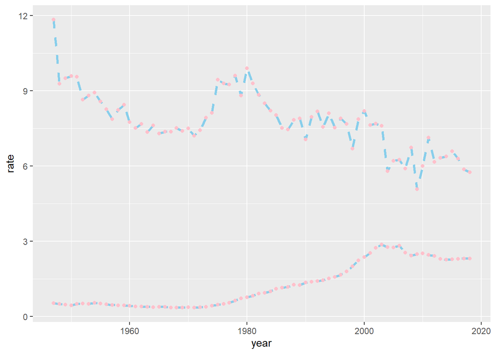

```r
library(dplyr)
library(readxl)
library(ggplot2)
data1<-read_excel("D:/Annie/Documents/GitHub/GitHubForRClass/RClassRepository/Week2/20190715/test/rateTest.xlsx")

ggplot(data=data1,aes(x=year,y=rate,group=supp))+geom_line(linetype="dashed",color="skyblue",size=1.2)+geom_point(color="pink",size=1.5)
```

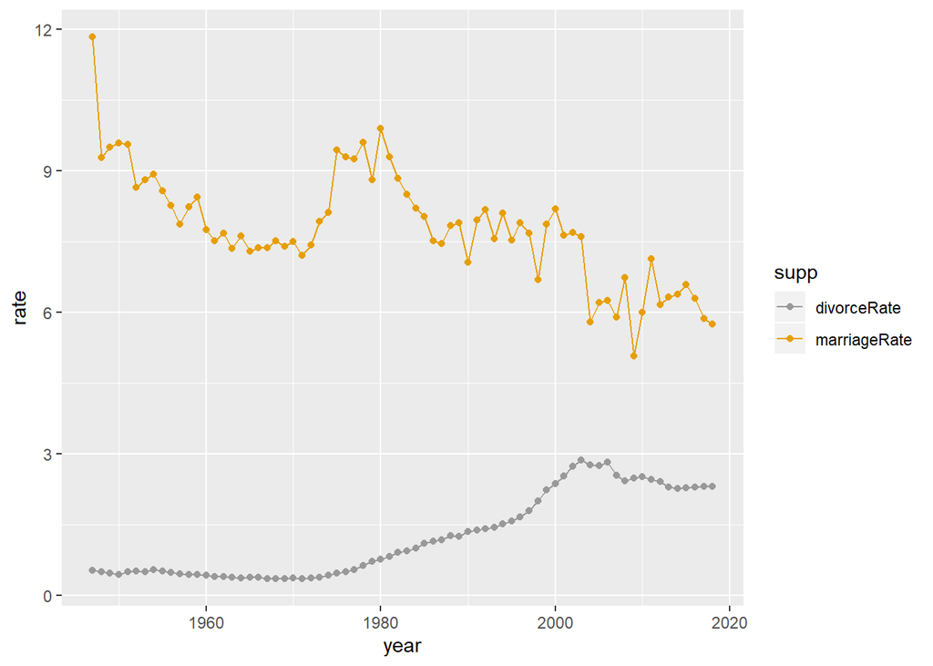

```r
p<-ggplot(data1, aes(x=year, y=rate, group=supp)) +
  geom_line(aes(color=supp))+
  geom_point(aes(color=supp))

# Use custom color palettes
p+scale_color_manual(values=c("#999999", "#E69F00", "#56B4E9"))
```

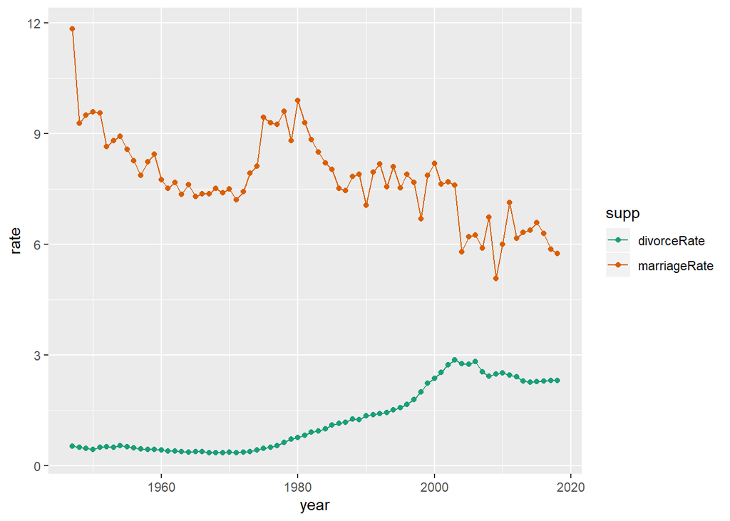

```r
# Use brewer color palettes
p+scale_color_brewer(palette="Dark2")
```

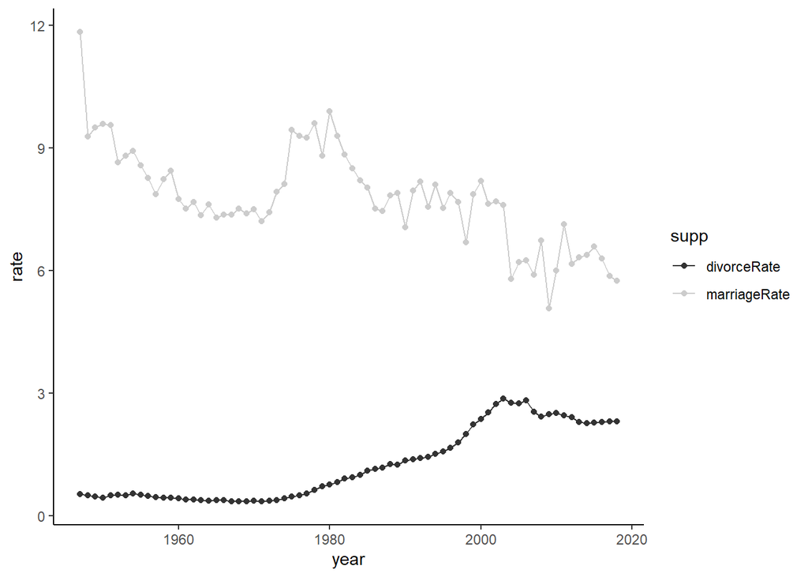

```r
# Use grey scale
p + scale_color_grey() + theme_classic()
```

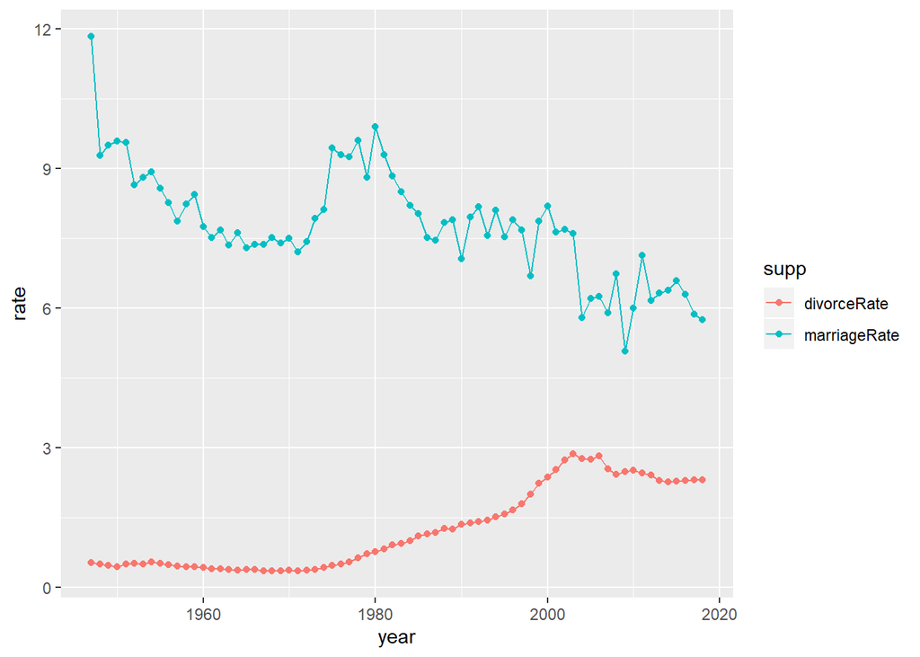

```r
p
```

##結婚率

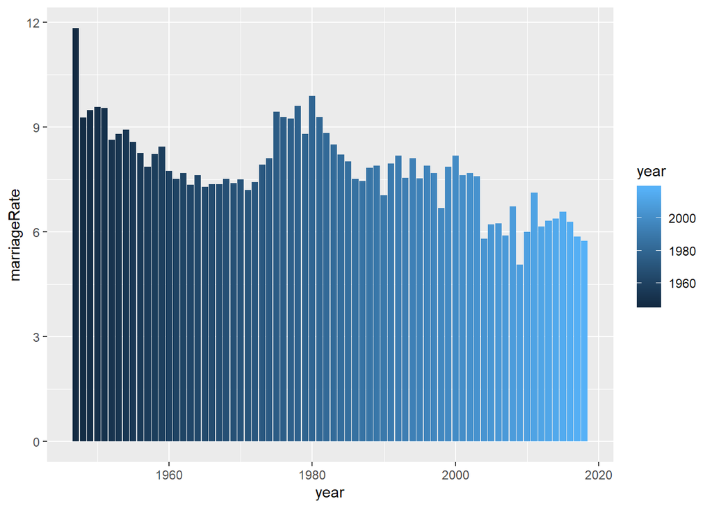

```r
data2<-read_excel("D:/download/Rclass/marriageRate.xls")
data4Marriage<-select(data2,"year","marriageRate")
ggplot(data=data4Marriage,aes(x=year,y=marriageRate,fill=year))+geom_bar(stat="identity")
```

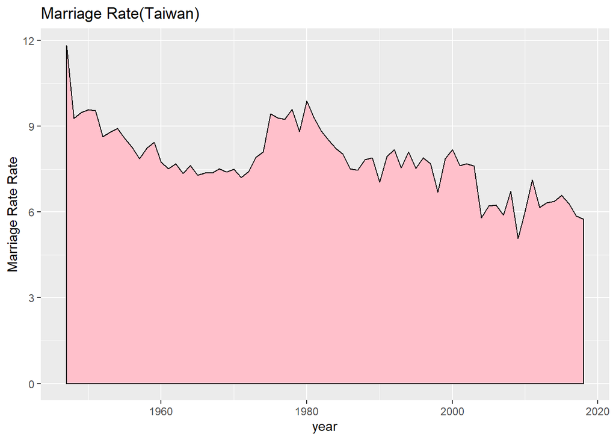

```r
library(ggplot2)
ggplot(data4Marriage, aes(x = year, y = marriageRate)) +
  geom_area(fill="pink", color="black") +
  labs(title = "Marriage Rate(Taiwan)",
       x = "year",
       y = "Marriage Rate Rate")
```

##離婚率

離婚率大增16.22％

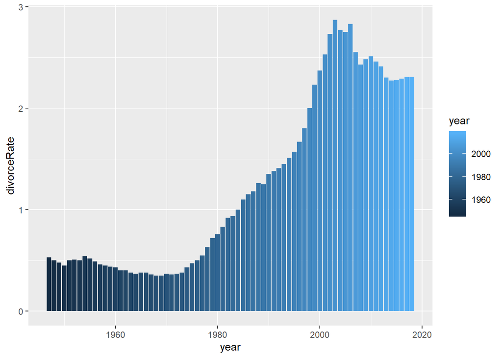

```r
data3<-read_excel("D:/download/Rclass/divorceRate.xls")
data4Divorce<-select(data3,"year","divorceRate")
ggplot(data=data4Divorce,aes(x=year,y=divorceRate,fill=year))+geom_bar(stat="identity")
```

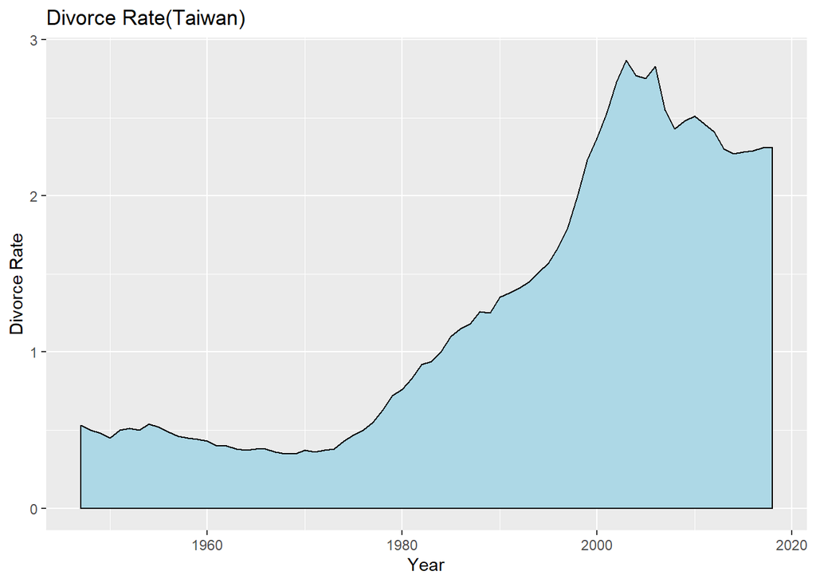

```r
ggplot(data4Divorce, aes(x = year, y = divorceRate)) +
  geom_area(fill="lightblue", color="black") +
  labs(title = "Divorce Rate(Taiwan)",
       x = "Year",
       y = "Divorce Rate")
```

根據內政部最新統計，今年1月有1萬4314對新人結婚，結婚率千分之7.15，由於農曆年前原本就是結婚旺季，若與去年同月相較，仍減少54對。今年1月也有4384對夫妻離婚，離婚率千分之2.19，比去年同期增加612對，離婚率大幅提高16.22％。

對於結婚少，離婚多的現象，兩性學者何春蕤表示，根本原因是社會變遷，人與人相互容忍度越來越低，彼此和樂相處變得不太容易。結婚的目的既然不能得到更多好處，反而變成麻煩事，年輕人自然就感到遲疑，甚至裹足不前。

兩性學者吳娟瑜指出景氣長年不佳，不少年輕人陷入低薪困境，使得許多人把經濟穩定擺在第一，感情生活其次，在現實生活的壓力下，更不想走入婚姻。吳娟瑜常聽到周遭一些友人說，寧願努力去賺自己的人生，也不要投入婚姻、家庭而失去自我。